# Phenotype Summary for *P. aegeria* GWAS

**Source file:** `qc_anna_data_phenotypes.xlsx`  
**Output file:** `Annas_phenotypes.tsv`  
**Samples:** 94 individuals (47 DD diapause cross, 47 NN non-diapause cross)

## 1. Source Data Overview

The xlsx file contains a single sheet with 94 rows (one per sample) and 16 columns. The columns cover DNA quality metrics, experimental metadata, and biological phenotypes from the diapause experiment.

### Columns in the source xlsx

| Column | Type | Description | Included in TSV? |
| --- | --- | --- | --- |
| Well | — | All empty (96-well plate position, unused) | No |
| nr | Integer | Sample number (1–94), maps to sample_id | Yes (as sample_id) |
| cabinet | Categorical | Growth cabinet assignment (C1, C2, C3) | Yes (coded 1/2/3) |
| cross | Categorical | Cross type: DD (diapause) or NN (non-diapause) | Yes |
| sample | Integer | Original sample number within cross | No (redundant) |
| qubit | Numeric | DNA concentration (Qubit), some with "?" flags | No (QC metric) |
| 260/280 | Numeric | DNA purity ratio | No (QC metric) |
| gel position | Mixed | Gel position, mostly empty, some labelled "pupa" | No (QC metric) |
| adult | Categorical | Whether individual survived to adult (y/n) | No (mostly empty) |
| Larval decision | Binary | 0 = direct development, 1 = diapause at larval stage | **Yes** |
| Pupal decision | Binary | 0 = direct development, 1 = diapause at pupal stage | **Yes** |
| Sex | Categorical | M or F | **Yes** (M=1, F=2) |
| P. Weight | Continuous | Pupal weight in grams | **Yes** |
| Days until pupation | Continuous | Days from experiment start to pupation | **Yes** |
| Adult weight | Continuous | Adult weight in grams (3 missing) | **Yes** |
| Days until eclosion | Continuous | Days from pupation to adult emergence | **Yes** |

### Columns excluded and why

- **Well** — entirely empty, no data
- **sample** — redundant with `nr` (the within-cross sample number)
- **qubit, 260/280, gel position** — DNA quality metrics, not biological phenotypes. Some have mixed-type data (e.g., "99.2?" with question marks)
- **adult** — 84 of 94 values are empty; the remaining entries include non-standard labels ("Data C3", "Data C2")

## 2. Phenotype File Structure

The output file `Annas_phenotypes.tsv` contains 12 columns:

| Column | Type | Values | GWAS usage |
| --- | --- | --- | --- |
| `sample_id` | ID | nr1–nr94 | Sample identifier |
| `cross` | Label | DD, NN | Reference label |
| `diapause` | Binary | 0 (NN) / 1 (DD) | Original GWAS phenotype |
| `larval_decision` | Binary | 0 / 1 | Binary trait GWAS |
| `pupal_decision` | Binary | 0 / 1 | Binary trait GWAS |
| `sex` | Binary | 1 (M) / 2 (F) | Covariate or sex GWAS |
| `pupal_weight_g` | Continuous | 0.0802–0.1963 g | Quantitative GWAS |
| `days_to_pupation` | Continuous | 23–119 days | Quantitative GWAS |
| `adult_weight_g` | Continuous | 0.0288–0.1013 g (3 NA) | Quantitative GWAS |
| `days_to_eclosion` | Continuous | 10–30 days | Quantitative GWAS |
| `cabinet` | Categorical | 1 / 2 / 3 | Environmental covariate |

### Preview (first 10 rows)

| sample_id | cross | diapause | larval_decision | pupal_decision | sex | pupal_weight_g | days_to_pupation | adult_weight_g | days_to_eclosion | cabinet | decision_match |
| --- | --- | --- | --- | --- | --- | --- | --- | --- | --- | --- | --- |
| nr1 | NN | 0 | 0 | 0 | 1 | 0.1092 | 27 | 0.0372 | 15 | 1 | Match |
| nr2 | NN | 0 | 0 | 0 | 1 | 0.1242 | 27 | 0.0425 | 15 | 1 | Match |
| nr3 | NN | 0 | 0 | 0 | 1 | 0.1237 | 27 | 0.0523 | 15 | 1 | Match |
| nr4 | NN | 0 | 1 | 1 | 1 | 0.1464 | 73 | 0.0566 | 28 | 1 | NN but diapause |
| nr5 | NN | 0 | 0 | 0 | 2 | 0.1541 | 33 | 0.0711 | 14 | 2 | Match |
| nr6 | NN | 0 | 0 | 0 | 2 | 0.1499 | 30 | 0.065 | 15 | 1 | Match |
| nr7 | NN | 0 | 1 | 1 | 1 | 0.1463 | 94 | nan | 27 | 1 | NN but diapause |
| nr8 | NN | 0 | 1 | 0 | 1 | 0.1508 | 81 | 0.0576 | 14 | 1 | NN but diapause |
| nr9 | NN | 0 | 1 | 0 | 2 | 0.1963 | 70 | 0.1013 | 15 | 1 | NN but diapause |
| nr10 | NN | 0 | 1 | 0 | 1 | 0.1627 | 76 | 0.0567 | 15 | 1 | NN but diapause |

## 3. Key Observations

**Important:** The original `diapause` phenotype (based on cross type DD/NN) does **not** perfectly match the actual `larval_decision` phenotype recorded for each individual:

- **23 DD individuals** actually chose direct development (larval_decision = 0)
- **24 NN individuals** actually entered diapause (larval_decision = 1)

This means the cross type is a *family-level* label reflecting parental genotype, not the individual's own developmental decision. The `larval_decision` column is the actual individual-level phenotype and may be more informative for GWAS.

**Pupal decision** is nearly invariant: only **7 individuals** (all from NN crosses) entered pupal diapause. This extremely low case count (7/94) makes it poorly suited as a standalone GWAS phenotype, but it captures a biologically distinct diapause checkpoint.

## 4. Binary Developmental Phenotypes

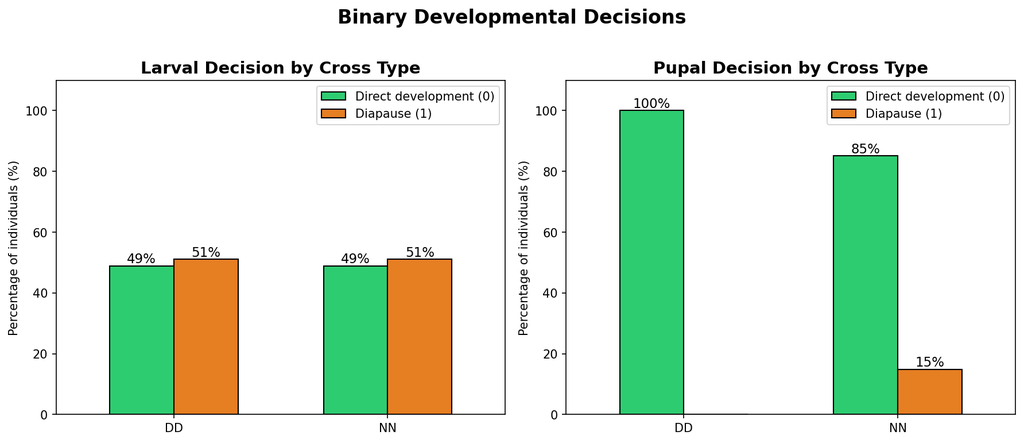

**Left:** Larval decision is split nearly 50/50 in *both* DD and NN crosses — cross type alone does not determine larval fate. **Right:** Pupal diapause occurs only in NN crosses, and even then only in 15% of individuals.

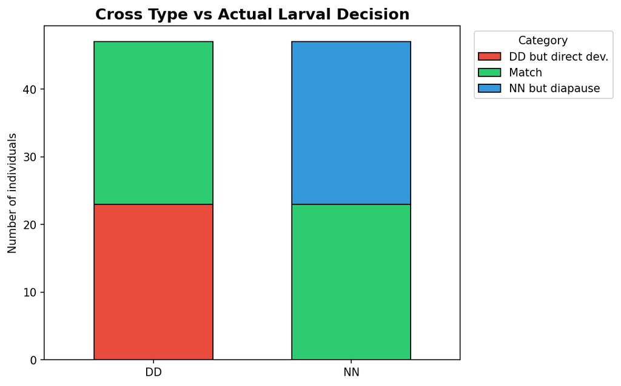

Breakdown showing which individuals match vs. mismatch their cross-type expectation. About half of both DD and NN individuals make the "unexpected" developmental choice, indicating strong individual-level variation beyond family genotype.

## 5. Development Time

Days to Pupation by Cross Type

| Cross | N | Mean | Std | Min | Median | Max |
| --- | --- | --- | --- | --- | --- | --- |
| NN | 47 | 53.2128 | 25.9598 | 24.0000 | 49.0000 | 119.0000 |
| DD | 47 | 47.8085 | 25.6825 | 23.0000 | 41.0000 | 101.0000 |

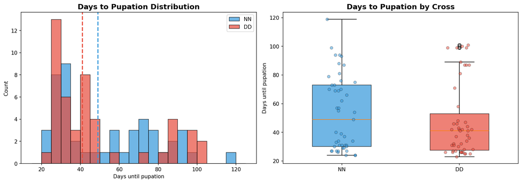

Both distributions are right-skewed, with a cluster of fast developers (23–35 days, predominantly direct developers) and a long tail of slow developers (50–120 days, predominantly diapausing individuals). DD median (41 days) is slightly lower than NN (49 days). The bimodal pattern reflects the two developmental pathways.

Days to Eclosion by Cross Type

| Cross | N | Mean | Std | Min | Median | Max |
| --- | --- | --- | --- | --- | --- | --- |
| NN | 47 | 17.0000 | 4.8723 | 13.0000 | 15.0000 | 30.0000 |
| DD | 47 | 14.9149 | 1.8513 | 10.0000 | 15.0000 | 22.0000 |

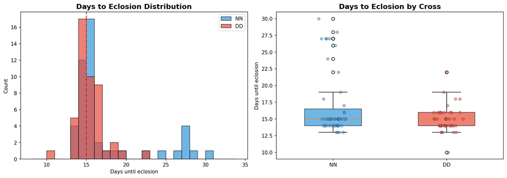

Most individuals eclose within 13–16 days after pupation. NN individuals show a longer tail (up to 30 days), likely driven by the 7 individuals that entered pupal diapause. DD eclosion times are tightly clustered (median 15 days), as none entered pupal diapause.

## 6. Body Mass Traits

Pupal Weight (g) by Cross Type

| Cross | N | Mean | Std | Min | Median | Max |
| --- | --- | --- | --- | --- | --- | --- |
| NN | 47 | 0.1492 | 0.0225 | 0.0981 | 0.1491 | 0.1963 |
| DD | 47 | 0.1475 | 0.0270 | 0.0802 | 0.1504 | 0.1892 |

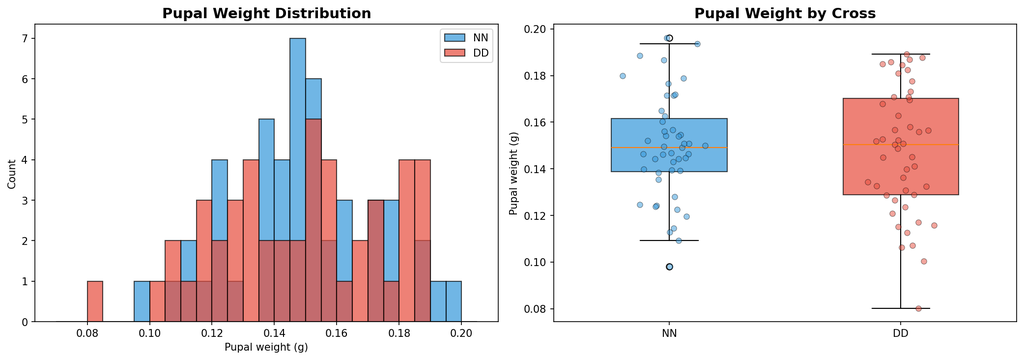

Pupal weight distributions are very similar between DD and NN crosses (means ~0.147 vs ~0.149 g). Both show broad, roughly normal distributions. This trait is likely influenced more by larval feeding duration and sex than by cross type.

Adult Weight (g) by Cross Type

| Cross | N | Mean | Std | Min | Median | Max |
| --- | --- | --- | --- | --- | --- | --- |
| NN | 44 | 0.0621 | 0.0168 | 0.0288 | 0.0608 | 0.1013 |
| DD | 47 | 0.0642 | 0.0190 | 0.0318 | 0.0617 | 0.0979 |

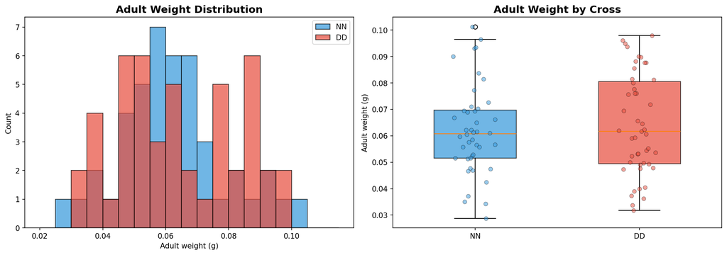

Adult weight (3 missing values, all from NN — likely individuals that did not survive to adulthood). Distributions overlap almost completely between DD and NN. Adult weight is roughly 40–45% of pupal weight, reflecting mass lost during metamorphosis.

## 7. Sex Distribution

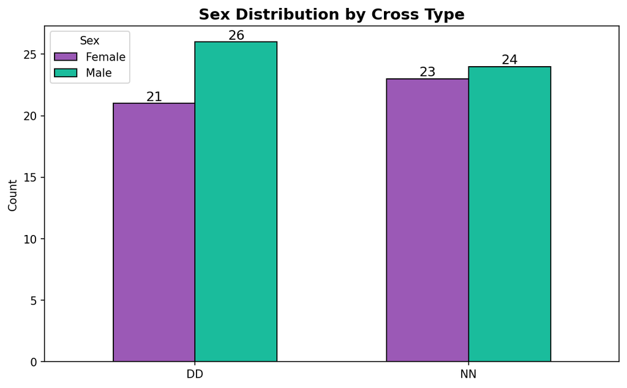

Sex ratios are balanced across both cross types: DD has 26M/21F, NN has 24M/23F. No strong sex bias in either cross. Sex should be included as a covariate in GWAS analyses, and can also serve as a positive control phenotype (should map to the Z chromosome in Lepidoptera).

## 8. Trait Correlations

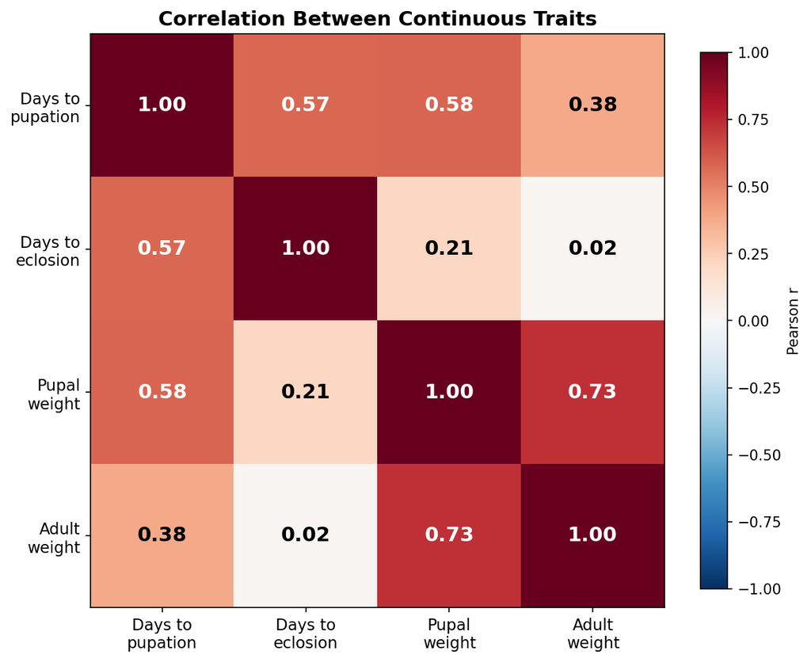

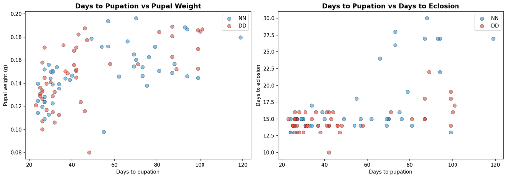

**Left:** Longer pupation times tend to produce slightly heavier pupae, with DD and NN individuals intermixed across the range. **Right:** The positive correlation between pupation time and eclosion time is driven primarily by the diapausing individuals (long pupation + delayed eclosion).

## 9. Cabinet (Environmental Covariate)

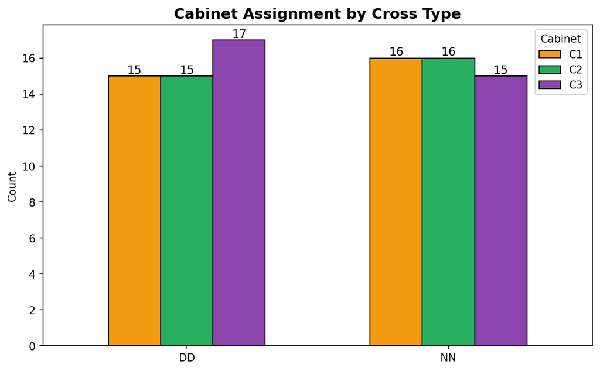

## 10. Recommendations for GWAS

| Phenotype | Type | GWAS suitability | Notes |
| --- | --- | --- | --- |
| `diapause` | Binary | Good (original) | Already run. Family-level label, not individual decision. |
| `larval_decision` | Binary | **Excellent** | Individual-level diapause decision. May reveal loci that the cross-level phenotype misses. |
| `pupal_decision` | Binary | Poor (underpowered) | Only 7 cases. Very low statistical power for GWAS. |
| `sex` | Binary | Good (positive control) | Should map to Z chromosome. Useful validation of GWAS pipeline. |
| `days_to_pupation` | Quantitative | **Excellent** | Continuous trait with broad range. Bimodal distribution reflects diapause biology. Consider log-transform. |
| `days_to_eclosion` | Quantitative | Moderate | Most values clustered at 14–16 days with a few outliers. May need rank-based normalisation. |
| `pupal_weight_g` | Quantitative | Good | Approximately normal distribution. Body size trait with ecological relevance. |
| `adult_weight_g` | Quantitative | Good | 3 missing values. Strongly correlated with pupal weight (r = 0.73). |

**Suggested covariates for all GWAS runs:** sex, cabinet, and the first N principal components from the PCA. For quantitative trait GWAS, also consider including `larval_decision` as a covariate to separate diapause-associated body size effects from direct genetic effects on growth.

Generated from `qc_anna_data_phenotypes.xlsx` — 2026-03-14 10:48